# Examining Transit-Oriented Development in Boston between 2009 and 2019

With transportation as a fundamental demand of people to access services and other urban resources, Transit-Oriented Development has contributed to enhancing the ease of access by creating dense and mixed communities close to the transit stations. However, households and individuals from various socio-economic backgrounds may value public transit differently. To find out the Transit-Oriented Development conditions in Boston, the brief will discuss how areas of Transit-Oriented Development in Boston are correlated with several socio-economic indicators between 2009 and 2019.

## 1. Wrangling the ACS data for 2009 and 2019.

```r
# Load Libraries

library(tidyverse)
library(tidycensus)
library(sf)
library(kableExtra)
library(gridExtra)

options(scipen=999)
options(tigris_class = "sf")

source("https://raw.githubusercontent.com/urbanSpatial/Public-Policy-Analytics-Landing/master/functions.r")

palette5 <- c("#f0f9e8","#bae4bc","#7bccc4","#43a2ca","#0868ac")
```

```r
census_api_key("c225553bc2ab27557539c33de3ebe928e378d800", overwrite = TRUE)
```

```r
#Get census tract data
tracts19 <-
  get_acs(geography = "tract",
          variables = c("B25026_001E","B02001_002E",
                        "B15001_050E","B15001_009E",
                        "B19013_001E", "B25058_001E",
                        "B06012_002E", "B01002_001E"),
          year=2019, state=25,
          county=025, geometry=TRUE) %>%
  st_transform('ESRI:102686')

tracts09 <-
  get_acs(geography = "tract",
          variables = c("B25026_001E","B02001_002E",
                        "B15001_050E","B15001_009E",
                        "B19013_001E", "B25058_001E",
                        "B06012_002E", "B01002_001E"),
          year=2009, state=25,
          county=025, geometry=TRUE) %>%
  st_transform('ESRI:102686')
```

```r
# Let's "spread" the data into wide form

tracts19 <-
  tracts19 %>%
  dplyr::select( -NAME, -moe) %>%
  spread(key = variable, value = estimate) %>%
  rename(TotalPop = B25026_001,
         Whites = B02001_002,
         FemaleBachelors = B15001_050,
         MaleBachelors = B15001_009,
         MedHHInc = B19013_001,
         MedRent = B25058_001,
         TotalPoverty = B06012_002,
         MedAge = B01002_001)

tracts09 <-
  tracts09 %>%
  dplyr::select( -NAME, -moe) %>%
  spread(key = variable, value = estimate) %>%
  rename(TotalPop = B25026_001,
         Whites = B02001_002,
         FemaleBachelors = B15001_050,
         MaleBachelors = B15001_009,
         MedHHInc = B19013_001,
         MedRent = B25058_001,
         TotalPoverty = B06012_002,
         MedAge = B01002_001)

# Let's create new rate variables using mutate

tracts19 <-
  tracts19 %>%
  mutate(pctWhite = ifelse(TotalPop > 0, Whites / TotalPop, 0),
         pctBachelors = ifelse(TotalPop > 0, ((FemaleBachelors + MaleBachelors) / TotalPop), 0),
         pctPoverty = ifelse(TotalPop > 0, TotalPoverty / TotalPop, 0),
         year = "2019") %>%
  dplyr::select(-Whites,-FemaleBachelors,-MaleBachelors,-TotalPoverty)

tracts09 <-
  tracts09 %>%
  mutate(pctWhite = ifelse(TotalPop > 0, Whites / TotalPop, 0),
         pctBachelors = ifelse(TotalPop > 0, ((FemaleBachelors + MaleBachelors) / TotalPop), 0),
         pctPoverty = ifelse(TotalPop > 0, TotalPoverty / TotalPop, 0),
         year = "2009") %>%
  dplyr::select(-Whites,-FemaleBachelors,-MaleBachelors,-TotalPoverty)

# Combine the tracts from the two years
allTracts <- rbind(tracts09,tracts19)
```

## 2. Wrangling the MBTA Rapid Transit Stop data.

```r
mbta <- st_read("https://hub.arcgis.com/datasets/massgis::mbta-rapid-transit-stops.geojson", quiet = TRUE)

# Remove Silver Line Stops
mbta <- mbta %>% filter(LINE != "SILVER")

mbta <- mbta %>% st_transform(st_crs(tracts19))
```

```r
#create .5 mile buffer from stations
stopBuffer <- st_buffer(mbta, 2640)

stopUnion <- st_union(stopBuffer)

mbtaBuffers <-
  rbind(
     stopBuffer %>%
      mutate(Legend = "Buffer") %>%
      dplyr::select(Legend),
     stopUnion %>%
      st_sf() %>%
      mutate(Legend = "Unioned Buffer"))
```

```r
buffer <- filter(mbtaBuffers, Legend=="Unioned Buffer")
```

```r
selectCentroids <-
  st_centroid(tracts19)[buffer,] %>%
  st_drop_geometry() %>%
  left_join(., dplyr::select(tracts19, GEOID), by = "GEOID") %>%
  st_sf() %>%
  dplyr::select(TotalPop) %>%
  mutate(Selection_Type = "Select by Centroids")
```

```r
#join TOD and non-TOD tracts by centroid method
allTracts.group <-
  rbind(
    st_centroid(allTracts)[buffer,] %>%
      st_drop_geometry() %>%
      left_join(allTracts) %>%
      st_sf() %>%
      mutate(TOD = "TOD"),
    st_centroid(allTracts)[buffer, op = st_disjoint] %>%
      st_drop_geometry() %>%
      left_join(allTracts) %>%
      st_sf() %>%
      mutate(TOD = "Non-TOD")) %>%
  #adjust for inflation
  mutate(MedRent.inf = ifelse(year == "2009", MedRent * 1.19, MedRent),
         MedHHInc.inf = ifelse(year == "2009", MedHHInc * 1.19, MedHHInc))
```

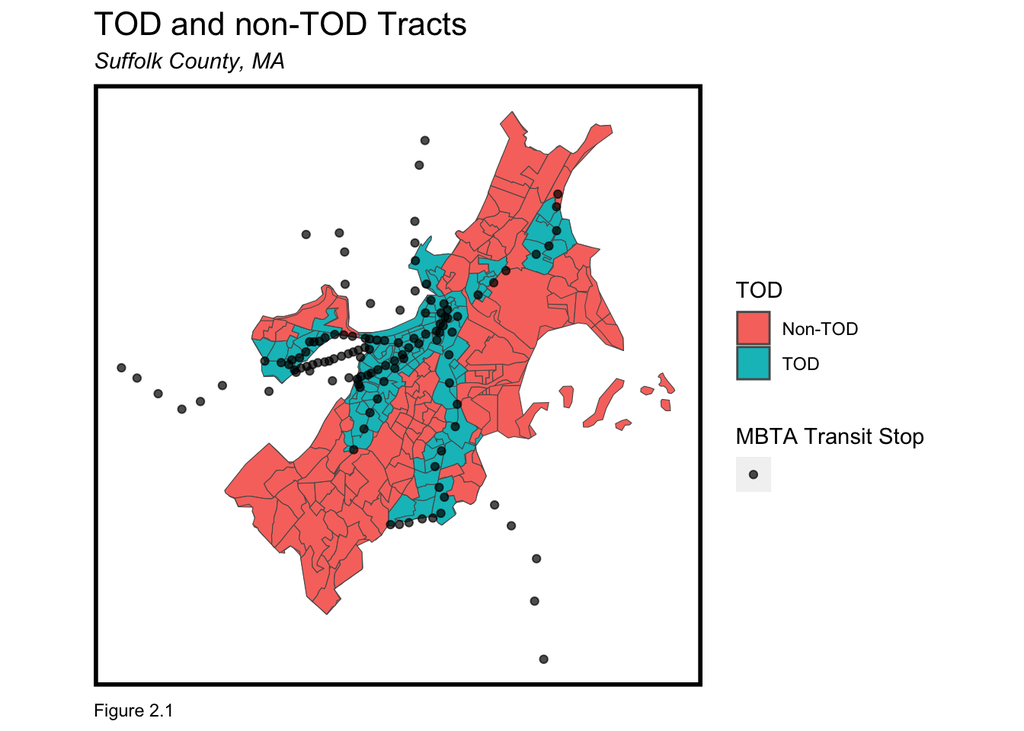

```r
#plot TOD vs non-TOD areas

ggplot() +
  geom_sf(data=allTracts.group, mapping = aes(fill = TOD)) +
  geom_sf(data=mbta, aes(color = ""), size= 1.5, alpha = 0.7) +
   scale_color_manual(values = "black",
                     name = "MBTA Transit Stop") +
  labs(title="TOD and non-TOD Tracts",
       subtitle="Suffolk County, MA",
       caption="Figure 2.1") +
  mapTheme()
```

Figure 2.1 shows the geographical areas of TOD and Non-TOD tracts in Boston, with two linear clusters of TOD tracts crossing the city center.

## 3. Comparing TOD and non-TOD areas between 2009 and 2019

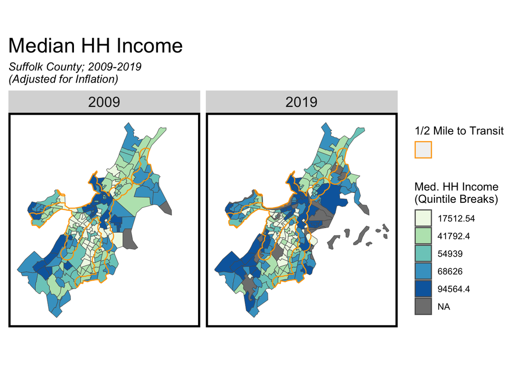

```r
buffer_clipped = st_intersection(buffer, allTracts.group) %>%
  st_union()

#geom_sf(data = selectCentroids %>% st_union(), color = "red", linewidth = 1, fill = NA) +

ggplot() +
  geom_sf(data = allTracts.group, aes(fill = q5(MedHHInc.inf))) +
  geom_sf(data = buffer_clipped, aes(color = ""), linewidth = 0.5, fill = NA) +
  facet_wrap(~year) +
  scale_color_manual(values = "orange",
                     name = "1/2 Mile to Transit") +
  scale_fill_manual(values = palette5,
                    labels = qBr(allTracts.group, "MedHHInc.inf"),
                    name = "Med. HH Income\n(Quintile Breaks)") +
  labs(title = "Median HH Income", subtitle = "Suffolk County; 2009-2019\n(Adjusted for Inflation)") +
  mapTheme() +
  theme(plot.title = element_text(size=20))
```

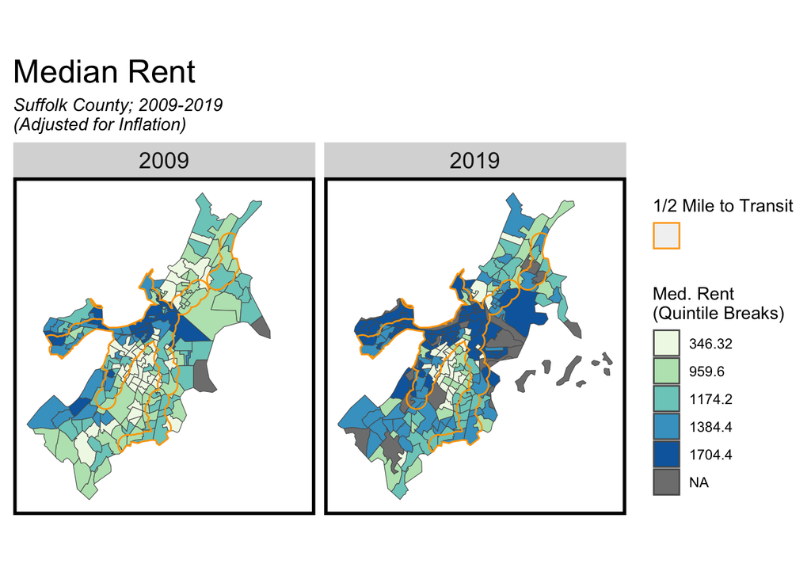

```r
ggplot() +
  geom_sf(data = allTracts.group, aes(fill = q5(MedRent.inf))) +
  geom_sf(data = buffer_clipped, aes(color = ""), linewidth = 0.5, fill = NA) +
  facet_wrap(~year) +
  scale_color_manual(values = "orange",
                     name = "1/2 Mile to Transit") +
  scale_fill_manual(values = palette5,
                    labels = qBr(allTracts.group, "MedRent.inf"),
                    name = "Med. Rent\n(Quintile Breaks)") +
  labs(title = "Median Rent", subtitle = "Suffolk County; 2009-2019\n(Adjusted for Inflation)") +
  mapTheme() +
  theme(plot.title = element_text(size=20))
```

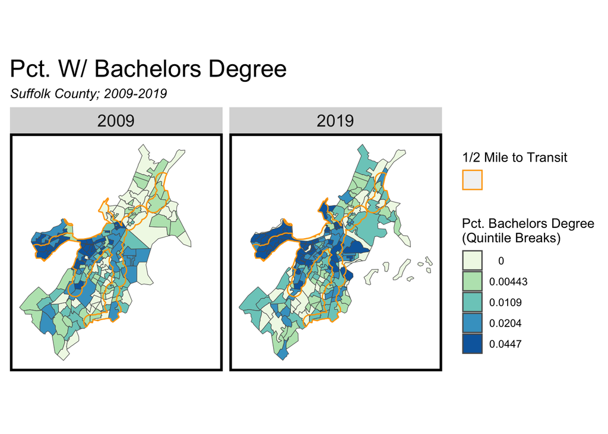

```r
ggplot() +
  geom_sf(data = allTracts.group, aes(fill = q5(pctBachelors))) +
  geom_sf(data = buffer_clipped, aes(color = ""), linewidth = 0.5, fill = NA) +
  facet_wrap(~year) +
  scale_color_manual(values = "orange",
                     name = "1/2 Mile to Transit") +
  scale_fill_manual(values = palette5,
                    labels = qBr(allTracts.group, "pctBachelors", 0),
                    name = "Pct. Bachelors Degree\n(Quintile Breaks)") +
  labs(title = "Pct. W/ Bachelors Degree", subtitle = "Suffolk County; 2009-2019") +
  mapTheme() +
  theme(plot.title = element_text(size=20))
```

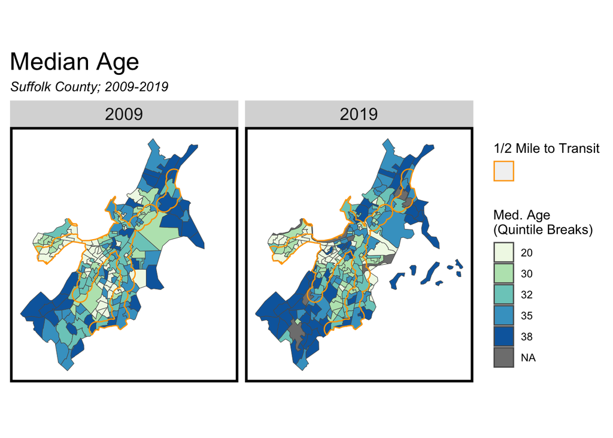

```r
ggplot() +
  geom_sf(data = allTracts.group, aes(fill = q5(MedAge))) +
  geom_sf(data = buffer_clipped, aes(color = ""), linewidth = 0.5, fill = NA) +
  facet_wrap(~year) +
  scale_color_manual(values = "orange",
                    name = "1/2 Mile to Transit") +
  scale_fill_manual(values = palette5,
                    labels = qBr(allTracts.group, "MedAge"),
                    name = "Med. Age\n(Quintile Breaks)") +
  labs(title = "Median Age", subtitle = "Suffolk County; 2009-2019") +
  mapTheme() +
  theme(plot.title = element_text(size=20))
```

Figure 3.1

Figure 3.1 illustrates the relationship between TOD and Non-TOD tracts in terms of median household income, median rent, percentage with Bachelors degree and median age in 2009 and 2019. Median household income and median rent have witnessed overall increase, particularly in the city center and surroundings. Meanwhile, there are generally higher percentage of people with bachelors degree in the TOD areas, and relatively people living in non-TOD areas have higher median age.

```r
#Create summary table first
allTracts.Summary <-
  st_drop_geometry(allTracts.group) %>%
  group_by(year, TOD) %>%
  summarize(Med_HH_Inc = mean(MedHHInc.inf, na.rm = T),
            Med_Rent = mean(MedRent.inf, na.rm = T),
            Percent_Bach = mean(pctBachelors, na.rm = T),
            Med_Age = mean(MedAge, na.rm = T))
```

```r
#table
allTracts.Summary %>%
  unite(year.TOD, year, TOD, sep = ": ", remove = T) %>%
  gather(Variable, Value, -year.TOD) %>%
  mutate(Value = round(Value, 2)) %>%
  spread(year.TOD, Value) %>%
  kable() %>%
  kable_styling(bootstrap_options = "striped") %>%
  footnote(general_title = "\n",
           general = "Figure 3.2")
```

| Variable | 2009: Non-TOD | 2009: TOD | 2019: Non-TOD | 2019: TOD |
| --- | --- | --- | --- | --- |
| Med_Age | 34.36 | 31.81 | 36.47 | 32.45 |
| Med_HH_Inc | 62426.60 | 62061.74 | 71846.30 | 74195.14 |
| Med_Rent | 1100.76 | 1242.81 | 1329.55 | 1578.84 |
| Percent_Bach | 0.01 | 0.04 | 0.03 | 0.05 |

Figure 3.2

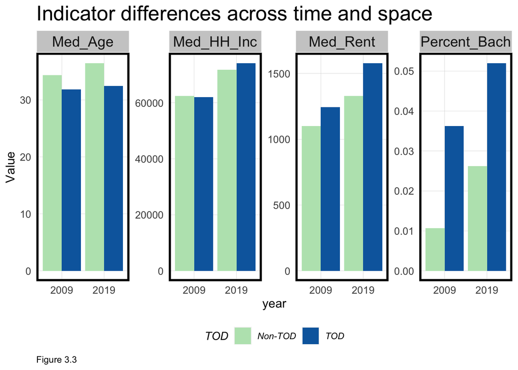

```r
#bar plots
allTracts.Summary %>%
  gather(Variable, Value, -year, -TOD) %>%
  ggplot(aes(year, Value, fill = TOD)) +
  geom_bar(stat = "identity", position = "dodge") +
  facet_wrap(~Variable, scales = "free", ncol=5) +
  scale_fill_manual(values = c("#bae4bc", "#0868ac")) +
  labs(title = "Indicator differences across time and space",
       caption = "Figure 3.3") +
  plotTheme() + theme(legend.position="bottom") +
  theme(plot.title = element_text(size=20))
```

Generally, TOD areas have slightly younger populations and much higher concentration of people with bachelors degree, which could result from higher reliance on public transit services. Median income in TOD areas have exceeded the non-TOD areas, with a higher rent in TOD areas and the gap is enlarging.

## 4. Dynamic changes of population and rent

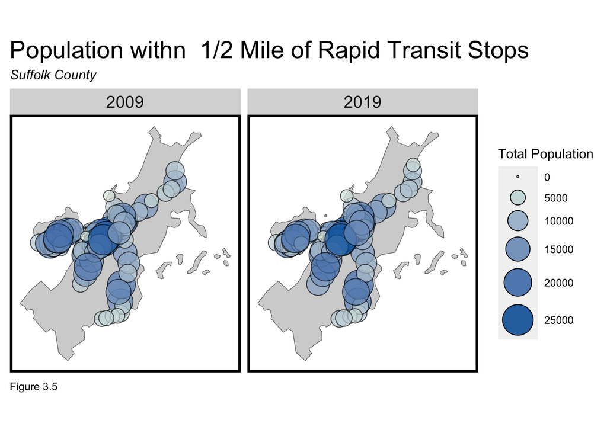

```r
# Calculate centroids
tract_centroids_all <- st_centroid(allTracts.group)
# Create half-mile buffers
tract_buffers_all <- st_buffer(tract_centroids_all, dist = 2640)

clipAll <-
  st_intersection(tract_buffers_all, mbta)

summaryTableAll <- clipAll %>%
  group_by(year, STATION) %>%
  summarize(Total_pop = sum(TotalPop, na.rm = TRUE),
           Rent = mean(MedRent.inf, na.rm = TRUE))

ggplot() +
  geom_sf(data = st_union(tracts19), fill = "lightgray") +
  geom_sf(data = summaryTableAll, aes(size = Total_pop, fill = Total_pop), shape = 21,
          alpha = 0.7, show.legend = "point") +
  facet_wrap(~year) +
  scale_size_continuous(range = c(0.5, 12)) +
  scale_fill_gradient(low = '#f0f9e8', high = '#0868ac') +
  labs(title = "Population withn  1/2 Mile of Rapid Transit Stops",
       subtitle = "Suffolk County", caption = "Figure 3.5") +
  mapTheme() +
  theme(plot.title = element_text(size=20)) +
  guides(size = guide_legend(title = "Total Population",
                             override.aes = list(alpha = 1, shape = 21)),
         fill = guide_legend(title = "Total Population"))
```

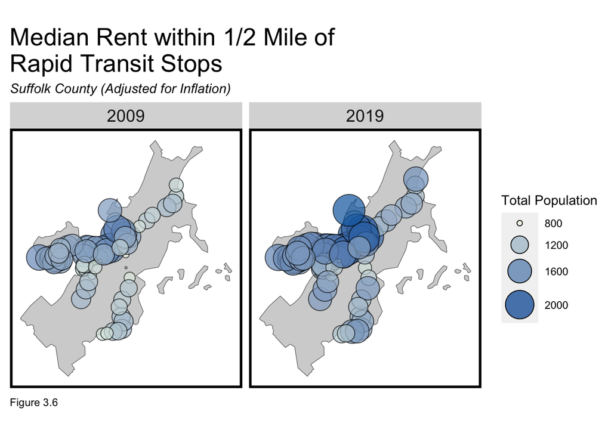

```r
ggplot() +
  geom_sf(data = st_union(tracts19), fill = "lightgray") +
  geom_sf(data = summaryTableAll, aes(size = Rent, fill = Rent), shape = 21,
          alpha = 0.7, show.legend = "point") +
  facet_wrap(~year) +
  scale_size_continuous(range = c(0.5, 12)) +
  scale_fill_gradient(low = '#f0f9e8', high = '#0868ac') +
  labs(title = "Median Rent within 1/2 Mile of\nRapid Transit Stops",
       subtitle = "Suffolk County (Adjusted for Inflation)",
       caption = "Figure 3.6") +
  mapTheme() +
  theme(plot.title = element_text(size=20)) +
  guides(size = guide_legend(title = "Total Population",
                             override.aes = list(alpha = 1, shape = 21)),
         fill = guide_legend(title = "Total Population"))
```

The population within 1/2 miles of the stations generally remain similar in 2009 and 2019, while the rent has increased dramatically, particularly in the city center.

## 5. Change of mean rent in terms of the distance to stations

```r
mbta_MRB <- multipleRingBuffer(st_union(mbta),
                                maxDistance = 31680,
                                interval =  2640)
```

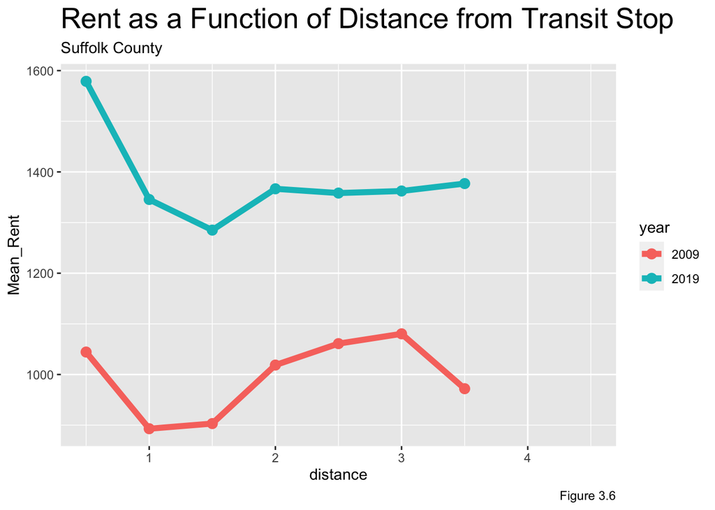

```r
tracts19.rings <- tracts19 %>%
  select(GEOID, year) %>%
  st_centroid() %>%
  st_join(mbta_MRB, join = st_intersects) %>%
  st_drop_geometry() %>%
  left_join(dplyr::select(tracts19, GEOID, MedRent, year),
            by=c("GEOID"="GEOID", "year"="year")) %>%
  st_sf() %>%
  mutate(distance = distance / 5280) #convert to miles

tracts09.rings <- tracts09 %>%
  select(GEOID, year) %>%
  st_centroid() %>%
  st_join(mbta_MRB, join = st_intersects) %>%
  st_drop_geometry() %>%
  left_join(dplyr::select(tracts09, GEOID, MedRent, year),
            by=c("GEOID"="GEOID", "year"="year")) %>%
  st_sf() %>%
  mutate(distance = distance / 5280) #convert to miles

allTracts.rings <- rbind(tracts09.rings, tracts19.rings)

allTracts.rings.summary <- st_drop_geometry(allTracts.rings) %>%
    group_by(distance, year) %>%
    summarize(Mean_Rent = mean(MedRent, na.rm=T))

ggplot(allTracts.rings.summary,
       aes(distance, Mean_Rent, colour=year)) +
      geom_point(size=3) +
  geom_line(size=2) +
  labs(title = "Rent as a Function of Distance from Transit Stop", subtitle = "Suffolk County",
       caption = "Figure 3.6") +
  theme(plot.title = element_text(size=20))
```

## 6. Conclusion

The findings of the socio-economic comparison between TOD and Non-TOD areas have illustrated that the neighborhoods within 1/2 miles of transit stops generally have higher concentration of younger population, higher rent, more people with bachelors degree and slightly higher median income. However, one limitation of the findings can result from the spatial bias that the souce of data is from census tracts, which is not detailed enough to fully represent the specific areas close to the transit stops. This can inform the TOD development to enhance the spatial equity to create more accessible public transit for wider range of people.